# Projekt z zakresu analizy danych

Autorzy

Karol Kowal, Marcin Kamiński

Dnia

29 Stycznia 2024 r.

[figure not shown]

# Wstęp

Tematem projektu jest analiza wybranych statystyk drużyn piłkarskich uczestniczących w rozgrywkach Premier League, czyli na najwyższym poziomie w angielskiej piłce w latach 2017-2023.

## Pytania badawcze

- Czy określenie Big Six jest dalej aktualne?
- Jakie statystyki definiują najlepsze drużyny ligi?

## Dane

Dane z których będziemy korzystać do analizy pozyskaliśmy ze stron [bref.com](https://fbref.com/) oraz [espn.com](https://www.espn.com/). Strony te nie mają opcji pobierania gotowych zestawień, więc użyliśmy metod web scrappingu poznanych podczas studiów. Poniżej znajduje się część całego zestawienia oraz objaśnienie zmiennych.

| Squad | Rk | Matches.played | Wins | Draws | Loses | Goals.for | Goals.against | Goal.difference | Points | Points.per.match | Expected.goals | Expected.goals.allowed | Expected.goals.difference | Expected.goals.difference.per.90.minutes | Attendance | Assists | Passes.completed | Passes.attempted | Short.passes.completed | Short.passes.attempted | Medium.passes.completed | Medium.passes.attempted | Long.passes.completed | Long.passes.attempted | Progressive.passes | Live.ball.passes | Dead.ball.passes | Passes.from.free.kicks | Through.balls | … |
| --- | --- | --- | --- | --- | --- | --- | --- | --- | --- | --- | --- | --- | --- | --- | --- | --- | --- | --- | --- | --- | --- | --- | --- | --- | --- | --- | --- | --- | --- | --- |
| Manchester City | 1 | 38 | 28 | 5 | 5 | 94 | 33 | 61 | 89 | 2.34 | 78.6 | 32.1 | 46.5 | 1.22 | 53249 | 69 | 23263 | 26642 | 11020 | 11888 | 9848 | 10836 | 1932 | 2849 | 2073 | 25047 | 1544 | 440 | 94 | … |
| Arsenal | 2 | 38 | 26 | 6 | 6 | 88 | 43 | 45 | 84 | 2.21 | 71.9 | 42.0 | 29.9 | 0.79 | 60191 | 64 | 18281 | 21969 | 8542 | 9478 | 7825 | 8821 | 1454 | 2548 | 2049 | 20293 | 1620 | 516 | 86 | … |
| Manchester Utd | 3 | 38 | 23 | 6 | 9 | 58 | 43 | 15 | 75 | 1.97 | 67.7 | 50.4 | 17.3 | 0.45 | 73671 | 42 | 16603 | 20525 | 8273 | 9294 | 6359 | 7306 | 1438 | 2651 | 1595 | 18827 | 1619 | 325 | 105 | … |
| Newcastle Utd | 4 | 38 | 19 | 14 | 5 | 68 | 33 | 35 | 71 | 1.87 | 72.0 | 39.6 | 32.4 | 0.85 | 52127 | 42 | 13925 | 17837 | 6433 | 7370 | 5580 | 6605 | 1523 | 2774 | 1618 | 16020 | 1746 | 447 | 88 | … |
| Liverpool | 5 | 38 | 19 | 10 | 9 | 75 | 47 | 28 | 67 | 1.76 | 72.6 | 50.9 | 21.7 | 0.57 | 53163 | 58 | 20043 | 24361 | 9023 | 10114 | 8561 | 9758 | 1962 | 3283 | 1992 | 22466 | 1811 | 416 | 103 | … |
| Brighton | 6 | 38 | 18 | 8 | 12 | 72 | 53 | 19 | 62 | 1.63 | 73.3 | 50.2 | 23.1 | 0.61 | 31477 | 46 | 19210 | 22888 | 9346 | 10305 | 7892 | 8919 | 1463 | 2462 | 1849 | 21109 | 1709 | 445 | 81 | … |
| Aston Villa | 7 | 38 | 18 | 7 | 13 | 51 | 46 | 5 | 61 | 1.61 | 50.2 | 52.5 | -2.2 | -0.06 | 39485 | 35 | 13782 | 17396 | 6109 | 6945 | 5981 | 6936 | 1345 | 2579 | 1242 | 15544 | 1794 | 599 | 54 | … |
| Tottenham | 8 | 38 | 18 | 6 | 14 | 70 | 63 | 7 | 60 | 1.58 | 57.1 | 49.7 | 7.4 | 0.20 | 61585 | 46 | 15972 | 19672 | 7333 | 8180 | 6707 | 7682 | 1499 | 2669 | 1449 | 17950 | 1655 | 404 | 74 | … |
| Brentford | 9 | 38 | 15 | 14 | 9 | 58 | 46 | 12 | 59 | 1.55 | 56.8 | 49.9 | 6.8 | 0.18 | 17078 | 36 | 11317 | 15551 | 5142 | 6116 | 4475 | 5602 | 1438 | 2947 | 1131 | 13766 | 1713 | 453 | 53 | … |
| Fulham | 10 | 38 | 15 | 7 | 16 | 55 | 53 | 2 | 52 | 1.37 | 46.2 | 63.8 | -17.6 | -0.46 | 23746 | 33 | 13974 | 18014 | 5867 | 6818 | 6222 | 7333 | 1551 | 2860 | 1326 | 16136 | 1818 | 471 | 20 | … |

**Objaśnienie zmiennych**

`Rk` - Miejsce w tabeli

`Squad` - Nazwa drużyny

`Matchhes.played` - Rozegrane mecze

`Wins` - Mecze wygrane

`Draws` - Remisy

`Loses` - Mecze przegrane

`Goals.for` - Bramki zdobyte

`Goals.against` - Bramki stracone

`Goal.difference` - Różnica bramek

`Points` - Punkty

`Points.per.match` - Średnia punktów zdobytych na mecz

`Expected.goals` - Oczekiwane bramki zdobyte wg. Opta (nie uwzględnia rzutów karnych wykonywanych po dogrywce)

`Expected.goals.allowed` - Oczekiwane bramki stracone wg. Opta (nie uwzględnia rzutów karnych wykonywanych po dogrywce)

`Expected.goals.difference` - Oczekiwana różnica bramek wg. Opta (nie uwzględnia rzutów karnych wykonywanych po dogrywce)

`Expected.goals.per.90.minutes` - Średnia oczekiwana różnica bramek na 90 minut wg. Opta (nie uwzględnia rzutów karnych wykonywanych po dogrywce)

`Attendance` - Średnia Frekwencja na meczach domowych

`Season` - Okres rozgrywek w latach.

`Age` - średnia ważona (względem rozegranych minut) wieku zawodników w drużynie

`Assists` - liczba asyst

`Passes.completed` - ilość celnych podań

`Passes.attempted` - ilość podań ogółem

`Short.passes.completed`- ilość celnych krótkich podań

`Short.passes.attempted` - ilość krótkich podań ogółem

`Medium.passes.completed` - ilość celnych średnich podań

`Medium.passes.attempted` - ilość średnich podań ogółem

`Long.passes.completed` - ilość celnych długich podań

`Long.passes.attempted` - ilość długich podań ogółem

`Progressive.passes` - Podania celne które przesuwają piłkę w stronę bramki przeciwnika co najmniej 10 yardów od jej najdalszego punktu przez ostatnie 6 podań, lub jakiekolwiek celne podanie w pole karne przeciwnika. Nie dotyczy podań z defensywy (40% boiska od strony własnej bramki)

`Live.ball.passes` - podania piłki w grze

`Dead.ball.passes` - podania piłki ze stałych fragmentów gry (rzuty wolne, rzuty rożne, rozpoczęcie gry, wyrzut z autu i rozpoczęcie od bramki)

`Passes.from.free.kicks` - podania z rzutów wolnych

`Through.balls` - celne podania między obrońcami na wolne pole

`Switches` - podania które przebyły co najmniej 40 yardów w poprzek boiska

`Crosses` - dośrodkowania

`Throw.in.taken` - wrzuty z autu

`Corner.kicks` - rzuty rożne

`Corner.kicks.in` - rzuty rożne dochodzące

`Corner.kicks.out` - rzuty rożne odchodzące

`Corner.kicks.straight` - krótkie rozegranie rzutu rożnego

`Passes.offside` - spalone

`Passes.blocked` - podania zablokowane

`Shoots.total` - liczba strzałów ogółem

`Shoots.on.target` - liczba strzałów celnych

`Average.shot.distance` - średni dystans strzału w yardach (rzuty karne się nie liczą)

`Free.kick.shots` - strzały z rzutów wolnych

`Shot.creating.actions` - dwie ofensywne akcje które prowadzą do oddania strzału, takie jak - podania, odbiory i wymuszone faule. Jeden gracz może wykonać wiele takich akcji. Możemy także uznać, strzelca za twórce akcji.

`SCA.Live.ball.pass` - celne podania “z gry” które doprowadziły do strzału

`SCA.Dead.ball.pass` - celne podania po stałym fragmencie które doprowadziły do strzału

`SCA.Take.on` - ominięcia przeciwnika doprowadziły do strzału

`SCA.Shot` - strzały, które doprowadziły do ponownego strzału

`SCA.Fouls.drawn` - sprowokowane faule, które doprowadziły do strzału

`SCA.Deffensive.action` - akcje defensywne które doprowadziły do oddania strzału

`Goal.creatiing.actions` - dwie ofensywne akcje które prowadzą do strzelenia bramki, takie jak - podania, odbiory i wymuszone faule. Jeden gracz może wykonać wiele takich akcji. Możemy także uznać, strzelca za twórce akcji.

`GCA.Live.ball.pass` - celne podania “z gry” które doprowadziły do strzelenia bramki

`GCA.Dead.ball.pass` - celne podania po stałym fragmencie które doprowadziły do strzelenia bramki

`GCA.Take.on` - ominięcia przeciwnika które doprowadziły do strzelenia bramki

`GCA.Shot` - strzały, które doprowadziły do ponownego strzelenia bramki

`GCA.Fouls.drawn` - sprowokowane faule, które doprowadziły do strzelenia bramki

`GCA.Deffensive.action` - akcje defensywne które doprowadziły do oddania strzelenia bramki

`Penalty.kicks.attempted` - rzuty karne ogółem (do bramki przeciwnika)

`Penalty.kicks.made` - wykorzystane rzuty karne

`Tackles` - próby odbioru

`Tackles.won` - skuteczne próby odbioru

`Tackles.def.3rd` - próby odbioru w defensywnej tercji boiska

`Tackles.mid.3rd` - próby odbioru w środkowej tercji boiska

`Tackles.att.3rd` - próby odbioru w ofensywnej tercji boiska

`Dribblers.tackled` - odbiory piłki z dryblingu

`Dribblers.challenged` - próby odbiorów piłki z dryblingu

`Challenges.lost` - nieudane próby odbiorów piłki z dryblingu

`Blocks` - zablokowane piłki (zawodnik stał na lini lotu piłki)

`Shots.blocked` - zablokowane strzały

`Blocked.passes` - zablokowane podania

`Interceptions` - przechwyty

`Clearances` - wybicia piłki

`Errors` - błędy prowadzące do oddania strzału przez przeciwnika

`Ball.recoveries` - odzyskane piłki

`Fouls.commited` - popełnione faule

`Yellow.cards` - żółte kartki

`Second.yellow.card` - drugie zółte kartki

`Red.cards` - czerwone kartki

`Own.goals` - bramki samobójcze

`Possession` - posiadanie piłki (liczone jako procent wykonanych podań podczas meczu)

`Touches` - liczba dotknięć piłki przez gracza (jeżeli zawodnik odebrał podanie, wykonał drybling i podał piłkę dalej liczone jest to jako jedno dotknięcie)

`Touches.def.pen` - liczba dotknięć piłki we własnym polu karnym

`Touches.def.3rd` - liczba dotknięć piłki w obronnej tercji boiska

`Touches.mid.3rd` - liczba dotknięć piłki w środkowej tercji boiska

`Touches.att.3rd` - liczba dotknięć piłki w ofensywnej tercji boiska

`Touches.att.pen` - liczba dotknięć piłki w polu karnym przeciwnika

`Takes.on.attempted` - próby ominięcia przeciwnika

`Takes.on.succesful` - udane próby ominięcia przeciwnika

`Times.tackled.during.take.on` - liczba sytuacji w której przeciwnik podczas mijania próbował odebrać piłkę

`Carries` - liczba sytuacji w których gracz kotnrolował piłkę stopą

`Total.carrying.distance` - dystanas w yardach który zawodnik przebył z piłką

`Progressive.carrying.distance` - dystanas w yardach który zawodnik przebył z piłką w strone bramki przeciwnika

`Progressive.carries` - sytuacje w których zawodnik prowadził piłkę w storne bramki linii bramki przeciwnika co najmniej 10 yardów od jej najdalszego punktu przez ostatnie 6 podań, lub jakiekolwiek doprowadzenie piłki w pole karne przeciwnika.

`Carries.into.final.third` - doprowadzenia piłki do ofensywnej tercji boiska

`Carreis.into.penalty.area` - doprowadzenia piłki w pole karne

`Miscontrols` - nieudane próby opanowania piłki

`Dispossessed` - straty piłki po odbiorach przeciwnika (nie liczą się odbiory po próbie ominięcia zawodnika)

`Fouls.drawn` - sytuacje w której zawodnik został sfaulowany

`Passes.recived` - otrzymane podania

`Progressive.passes.recived` - otrzymane podania progresywne

`Aerials.won` - wygrane walki w powietrzu

`Aerial.lost` - przegrane walki w powietrzu

`Substitute.apperances` - ilość dokonanych zmian

`Matchehs.as.unused.sub` - mecze bez wykorzystania wszystkich zmian

Wszystkie dane które pobraliśmy z ww. stron były kompletne, więc nie musimy martwić się ich uzupełnianiem. Ponieważ nasz zbiór jest dosyć spory, zdecydowaliśmy się podzielić go na cztery części: strzały, podania, posiadanie piłki i obrona.

# Charakterystyka ligi

Od lat w żargonie kibiców i ekspertów angielskiej piłki funkcjonuje Big Six oznaczające sześć najlepszych drużyn występujących w Premier League są to: Manchester United, Arsenal, Chelsea, Liverpool, Tottenham oraz Manchester city.

[interactive chart not shown]

Na mapie powyżej zaznaczyliśmy stadiony drużyn zaliczających się do Big Six. Aż trzy ekipy są z Londynu, dwie z Manchesteru i jedna z Liverpoolu.

### Postawowe wykresy/wizualizacje

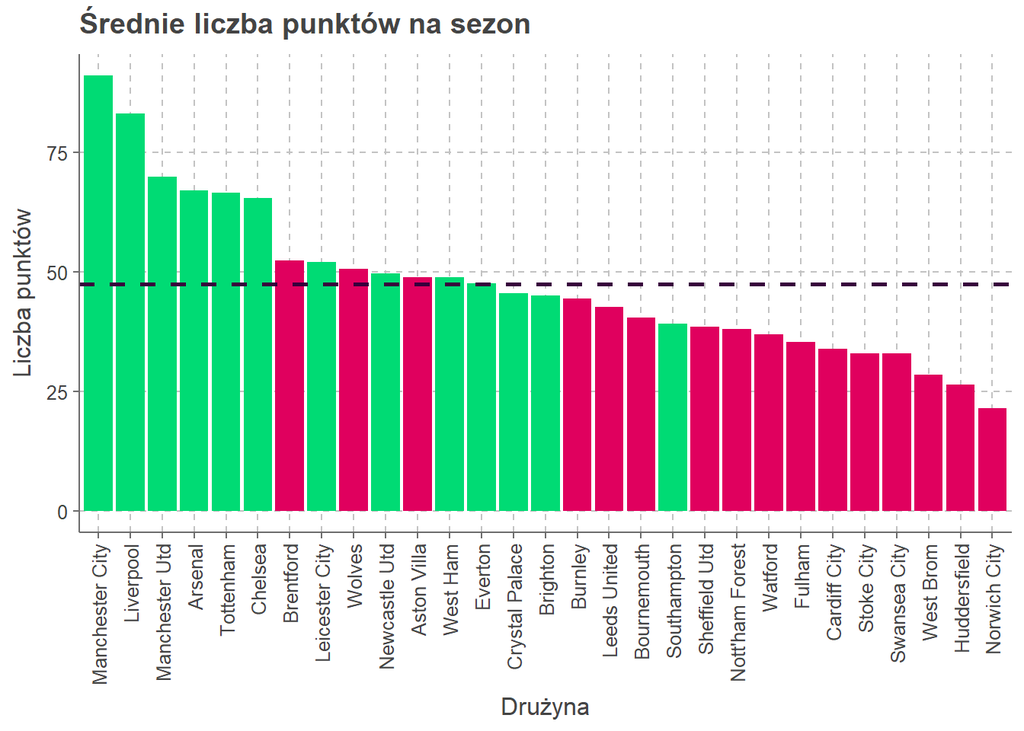

Wykres 1: Średnia liczba punktów na sezon

Na powyższym wykresie ( Wykres 1 ) widzimy średnią liczbę punktów ze wszystkich sezonów, na zielono zaznaczone są drużyny które przez badany okres zawsze grały w pierwszej klasie rozgrywkowej. Przerywana linia reprezentuje średnią liczbę punktów wszystkich zespołów. Widzimy, że Bix Six zawsze utrzymują wysoki poziom, podczas gdy reszta ligi ma wahania formy.

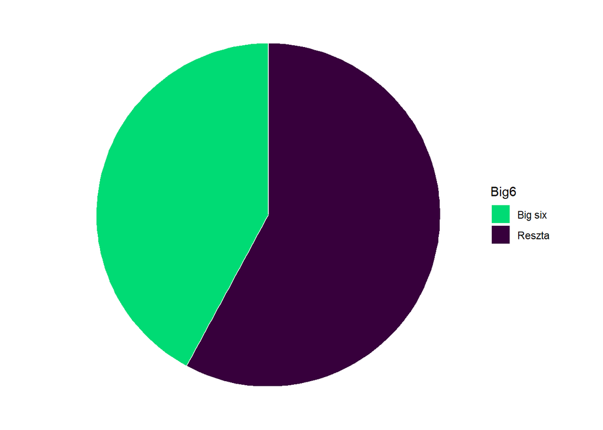

Wykres 2: Wykres kołowy

Na wykresie kołowym ( Wykres 2 ) widzimy, że Bix Six zdobyło ponad jedną trzecią wszystkich możliwych punktów do zdobycia w przeciągu ostatnich 5 lat. Warto zaznaczyć, że pozostałych zespołów w każdym sezonie jest ponad dwa razy więcej bo aż 14.

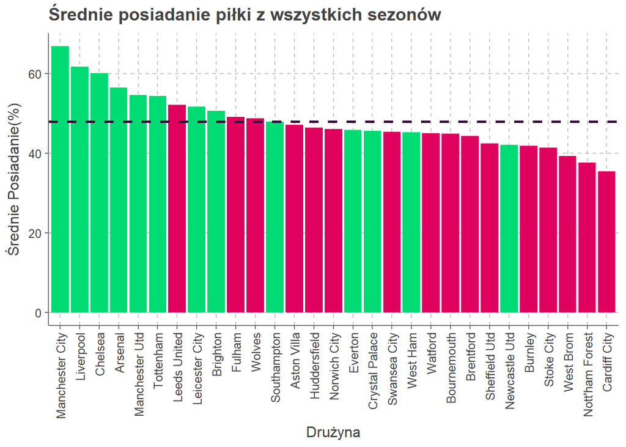

Wykres 3: Średnia posiadanie piłki

Na powyższym wykresie ( Wykres 3 ) widzimy średnie posiadanie piłki każdej drużyny ze wszystkich sezonów, na zielono zaznaczone są drużyny które przez badany okres zawsze grały w pierwszej klasie rozgrywkowej. Przerywana linia reprezentuje średnią średnich wszystkich zespołów. Widzimy, że najlepsze zespoły utrzymują się przy piłce dłużej podczas meczu, jednak nie jest to reguła.

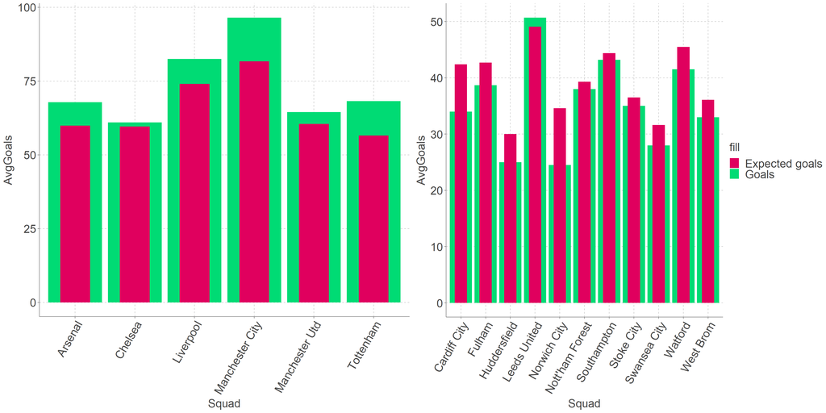

Wykres 4: Expected Goals

Na Wykres 4 porównaliśmy Przewidywane Bramki do faktycznie zdobytych goli. Po lewej przedstawiliśmy drużyny z Big Six, a po prawej drużyny, które przynajmniej raz spały z ligi. Widzimy, że drużyny z Big Six strzelają więcej bramek niż stwarzają dogodnych sytuacji, czyli zawodnicy zdobywają bramki nawet w trudnych sytuacjach. Drużyny z drugiego wykresu mają odwrotną sytuację - więcej przewidywanych bramek niż faktycznie strzelonych. Oznacza to, że zawodnicy tych ekip marnują nawet dogodne sytuacje. Może to świadczyć o poziomie zawodników, przez który kluby te nie są w stanie utrzymać się w lidze.

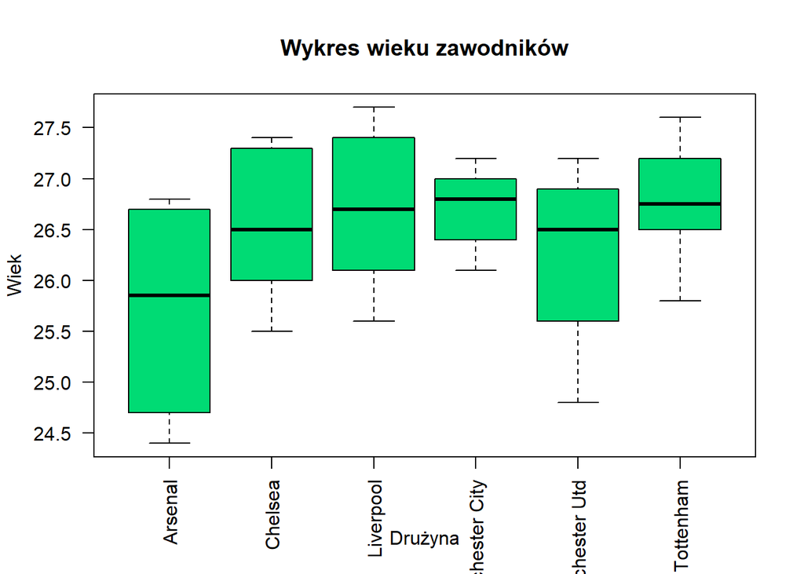

Wykres 5: Wiek

Na wykresie pudełkowym Wykres 5 widzimy średni wiek zawodników drużyn Bix Six w ciągu ostatnich 6 lat. Najmłodszą kadrą może pochwalić się Arsenal, z kolei najstarszą Manchester City, który stawia na doświadczenie. Oprócz tego możemy wywnioskować, że w Manchester City oraz Tottenham większość stawia raczej na tych samych graczy ponieważ ich wykres jest “najmniej rozciągnięty”. Z kolei w Arsenalu przewinęło się sporo rożnych graczy ponieważ dane z ostatnich 5 lat są najbardziej rozbieżne.

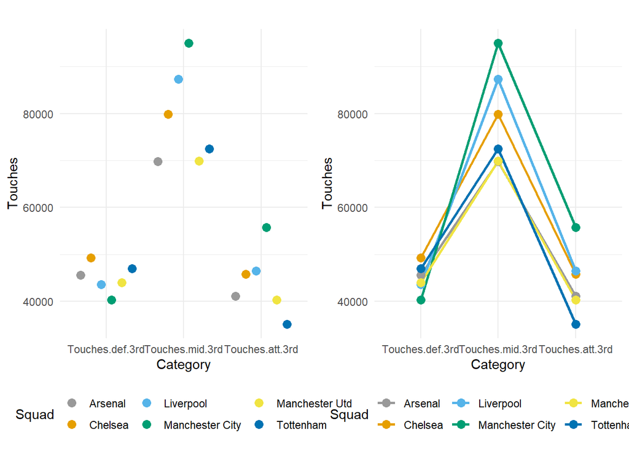

Wykres 6: Konatkty z piłką w różnych częściach boiska

Na powyższym wykresie Wykres 6 przedstawiliśmy dotknięcia piłek przez zawodników drużyn z Big Six w różnych miejscach boiska. Boisko zostało podzielone na trzy części: okolice własnego pola karnego, środek boiska oraz okolice pola karnego przeciwnika. Widzimy, że każda z najlepszych ekip najwięcej kontaktów z piłką ma w środkowej części boiska - to tam budowane są akcje. Możemy zaobserwować, że w przypadku najlepszej z drużyn czyli Manchesteru City różnica pomiędzy kontaktami pod polem karnym przeciwnika jest zdecydowanie większa niż w okolicach własnego pola karnego. Zupełnie odwrotnie ma Tottenham, a pozostałe ekipy mają podobną ilość zarówno pod jedną jak i drugą bramką.

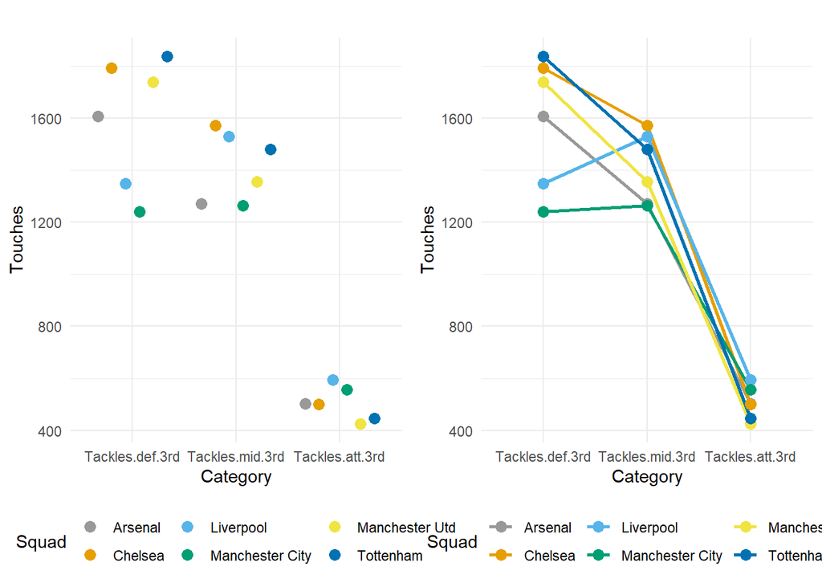

Wykres 7: Odbiory piłki w różnych częściach boiska

Na wykresie odbiorów Wykres 7 obserwujemy, że Liverpool odbiera zdecydowanie więcej piłek w środkowej części boiska, przez co nie dopuszcza przeciwników pod swoje pole karne. Manchester City podobnie, ale nie jest aż tak skuteczny w środku jak Liverpool. Oznacza to, że te dwie drużyny grają wysokim pressingiem i mają między innymi dzięki temu najlepsze wyniki. Reszta drużyn z wielkiej szóstki dopuszcza przeciwników na swoją połowę i tak odbiera piłkę

# Analiza głównych składowych

W naszej analizie, skoncentrowaliśmy się wyłącznie na zmiennych reprezentujących zachowania piłkarzy na boisku. Wybór ten był podyktowany chęcią zrozumienia kluczowych strategii, taktyk i stylów gry, które charakteryzują różne drużyny. Wierzymy, że te zmienne mogą dostarczyć cennych informacji o dynamice gry i pomóc w identyfikacji czynników, które przyczyniają się do sukcesu drużyn w Premier League.

|  | percentage of variance | cumulative percentage of variance |
| --- | --- | --- |
| comp 1 | 47.11 | 47.11 |
| comp 2 | 10.47 | 57.57 |
| comp 3 | 7.98 | 65.55 |
| comp 4 | 5.53 | 71.09 |
| comp 5 | 4.70 | 75.79 |
| comp 6 | 3.77 | 79.55 |
| comp 7 | 2.87 | 82.43 |
| comp 8 | 2.46 | 84.89 |

Na podstawie przeprowadzonej analizy głównych składowych (PCA) na naszych danych, można zauważyć, że pierwsza składowa główna (Dim.1) wyjaśnia 47% całkowitej wariancji. Sugeruje to, że Dim.1 ma największy wpływ na model.

|  | coord.Dim.1 | coord.Dim.2 | coord.Dim.3 | coord.Dim.4 | coord.Dim.5 | coord.Dim.6 |
| --- | --- | --- | --- | --- | --- | --- |
| Manchester City | 19.38 | -4.94 | 0.09 | 0.22 | 0.20 | 0.26 |
| Liverpool | 13.49 | -1.82 | 3.56 | 2.09 | -0.39 | -2.54 |
| Chelsea | 10.34 | 1.27 | 0.66 | 0.19 | 0.21 | -0.67 |
| Arsenal | 7.12 | -1.74 | -1.95 | -1.38 | -0.49 | 0.00 |
| Manchester Utd | 6.81 | 0.26 | -0.92 | -0.46 | 0.42 | -0.04 |
| Tottenham | 5.51 | 1.44 | -0.60 | -1.11 | 0.67 | 0.04 |
| Leicester City | 2.25 | 3.54 | 0.50 | 0.44 | 0.95 | 0.62 |
| Brighton | 1.27 | -0.27 | 0.70 | 0.30 | -2.56 | 0.83 |

Jeżeli posortujemy drużyny względem tego jak są wyjaśniane przez pierwszy wymiar, możemy zauważyć ciekawą zależność - mianowicie pierwsze sześć drużyn to wspomniane wcześniej Big six, dodatkowo na pierwszym miejscu widzimy Manchester City który w ostatnich latach dominował angielską piłkę. Możemy potraktować to jako swojego rodzaju ranking.

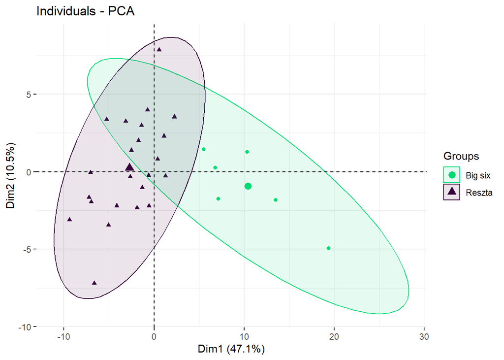

Tak dwa pierwsze wymiary prezentują się na płaszczyźnie PCA. Możemy już tutaj zauważyć, że pierwszy wymiar podzielił nam drużyny na z Big six i resztę.

Spójrzmy teraz jaki poszczególne zmienne mają wpływ na pierwszy - najważniejszy wymiar, pomoże nam to zrozumieć jakimi elementami gry wyróżniają się lepsze zespoły na tle tych gorszych.

### Podania

|  | coord.Dim.1 |
| --- | --- |
| Short.passes.attempted | 0.9506176 |
| Medium.passes.attempted | 0.9478414 |
| Long.passes.attempted | -0.3052127 |
| Switches | 0.7438782 |
| Crosses | 0.4613505 |

Analiza korelacji między Dim.1 a różnymi typami podań pokazuje, że najlepsze drużyny wykonują dużą liczbę krótkich i średnich podań, które mają silną dodatnią korelację z Dim.1. Z drugiej strony, te drużyny wykazują ujemną korelację z długimi podaniami, co sugeruje, że ten typ podań jest częściej stosowany przez słabsze drużyny.

### Gra w defensywie

|  | coord.Dim.1 |
| --- | --- |
| Tackles.def.3rd | -0.6380243 |
| Tackles.mid.3rd | 0.0078210 |
| Tackles.att.3rd | 0.5475179 |
| Blocks | -0.7354546 |
| Fouls.commited | -0.3498733 |

W kontekście strategii obronnych, najlepsze drużyny często odbierają piłkę na połowie przeciwnika, podczas gdy inne drużyny często bronią się na swojej połowie, blokują strzały i uciekają się do fauli. Wszystkie drużyny wykazują zbliżoną częstotliwość odbioru piłki w środkowej części boiska.

### Rzuty rożne

|  | coord.Dim.1 |
| --- | --- |
| Corner.kicks.in | -0.1851328 |
| Corner.kicks.out | 0.7261003 |
| Corner.kicks.straight | -0.2734796 |

Co ciekawe najlepsze drużyny rozgrywają swoje rzuty rożne najczęściej w sposób odchodzący od bramki, czyli z prawej strony rzut rożny wykonuje zawodnik prawonożny a z lewej lewonożny. Raczej unikają krótkich rozegrań i dośrodkowań dochodzących do bramki.

### Gra z piłką

|  | coord.Dim.1 |
| --- | --- |
| Touches.def.pen | -0.4122790 |
| Touches.def.3rd | 0.3710275 |
| Touches.mid.3rd | 0.9318565 |
| Touches.att.3rd | 0.9227807 |
| Touches.att.pen | 0.9140816 |

Zawodnicy najlepszych zespołów najwięcej kontaktów z piłką mają w środkowej części i na połowie przeciwnika. Widać, że przeciwnicy często zamykani są w swoim polu karnym, najlepsze drużyny mają dużą korelację z kontaktami w polu karnym przeciwnika, natomiast ujemną we własnym. We własnym polu karnym dużo kontaktów mają słabsze drużyny ponieważ muszą piłkę odbierać i wybijać aby nie stracić bramki.

# Analiza skupień

Podczas analizy modelu PCA mogliśmy zauważyć już pewne różnice pomiędzy wielką szóstką a resztą zestawienia. Przyjrzyjmy się teraz temu dokładniej.

### Statystyka Hopkinsa

Po pierwsze musimy sprawdzić czy nasz zbiór posiada tendencje do grupowania się, aby to zbadać użyjemy statystyki Hopkinsa.

```
$H
[1] 0.3444739
```

Otrzymana wartość statystyki jest mniejsza niż 0.5 możemy uznać, że zbiór posiada tendencje do grupowania się

## Podejście niehierarchiczne

### Dobór odpowiedniej liczby klastrów

Do wyznaczenia odpowiedniej liczby klastrów przyda nam się macierz odległości stworzona z naszych danych. Wszystkie zmienne w naszym zbiorze są ilościowe zatem do wyznaczenia tej macierzy zastosujemy metodę euklidesową.

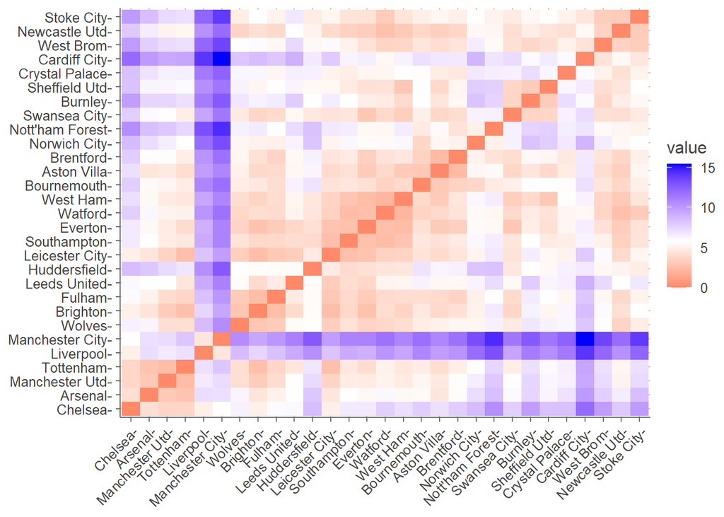

Na heatmapie utworzonej na podstawie macierzy odległości możemy zauważyć dwa skupiska:

- Jedno mniejsze zawierające 6 drużyn z wcześniej wspomnianego “Big six”
- Drugie większe zawierające pozostałe drużyny ligi

Sprawdźmy teraz co na ten temat mówią inne sposoby estymowania najlepszej liczby klastrów

|  | Optymalna liczba klastrów |
| --- | --- |
| kl | 2 |
| ch | 2 |
| hartigan | 6 |
| cindex | 4 |
| db | 10 |
| silhouette | 2 |
| duda | 2 |
| pseudot2 | 2 |
| beale | 8 |
| ratkowsky | 2 |
| ball | 3 |
| ptbiserial | 2 |
| gap | 2 |
| frey | 2 |
| mcclain | 2 |
| gamma | 10 |
| gplus | 10 |
| tau | 2 |
| dunn | 9 |
| sdbw | 10 |

Większość metod również sugeruje nam podział zbioru na dwie grupy co też uczynimy w dalszej analizie.

Do podziału naszego zbioru zdecydowaliśmy się użyć metody k-średnich.

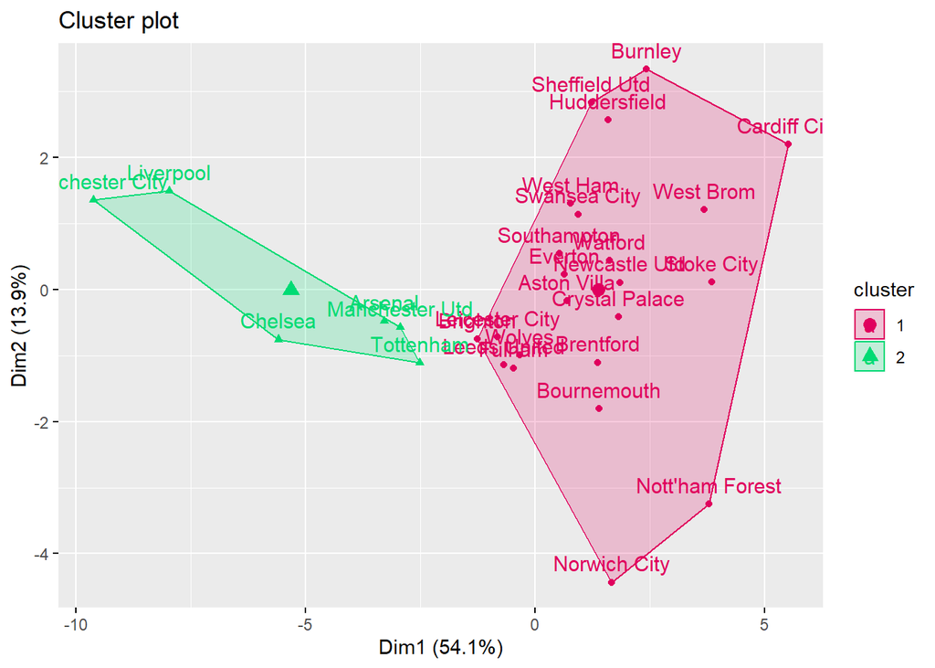

## Podejście hierarchiczne

Najlepszym sposobem na wizualizację hierarchicznego podziału zbioru jest dendrogram. Do budowy naszego zdecydowaliśmy się metody complete linkeage.

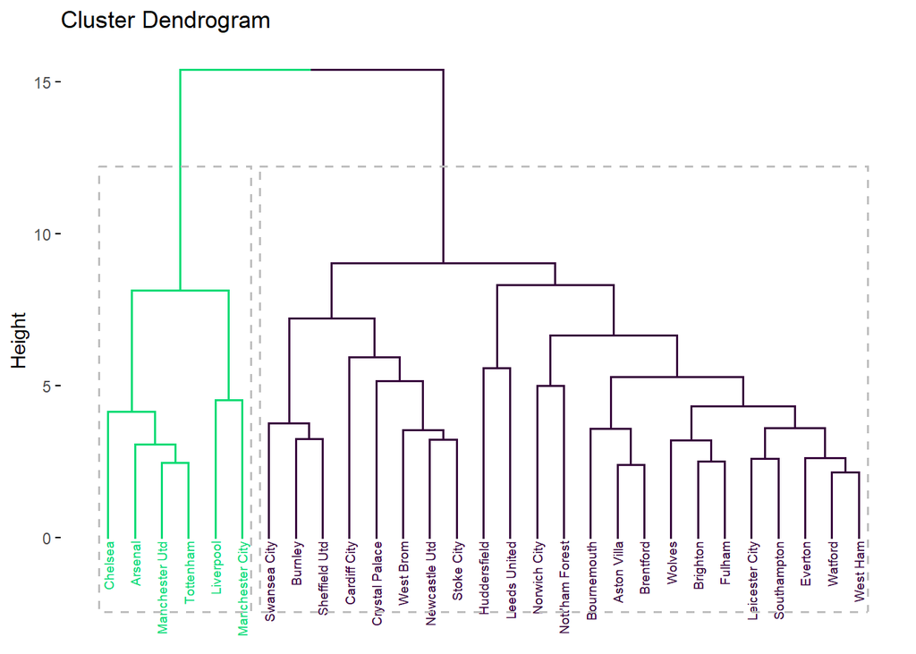

Jak widzimy dendrogram również wyodrębnił dwie grupy takie same jak w podejściu niehierarchicznym.

# Analiza dyskryminacyjna

Aby czy określenie big six jest dalej aktualne stworzymy model analizy dyskryminacyjnej a następnie zrobimy predykcję na zbiorze danych z obecnie trwającego sezonu. Do stworzenia modelu posłużymy się zmiennymi utworzonymi za pomocą modelu PCA

### Założenia

#### Brak współliniowości

Jednym z głównych założeń budowy modelu funkcji dyskryminacyjnej jest brak silnej korelacji między zmiennymi, do wykrycia i pozbycia się ich posłużyliśmy się funkcją `vif`. Zobaczmy jakie zmienne nam zostały i jak teraz wyglądają ich korelacje.

[figure not shown]

#### Liczebność próby i równoliczność grup

Zakłada się, że w modelach analizy dyskryminacyjnej obserwacji było co najmniej 4-5 razy więcej niż zmiennych użytych w modelu, zaleca się również, żeby wszystkie grupy w analizie dyskryminacyjnej były równoliczne w naszym przypadku w każdym sezonie Big six to jedynie 30% wszystkich drużyn w tabeli co tworzy dosyć sporą dysproporcję. Pozbędziemy się zatem losowo kilku obserwacji drużyn spoza tego grona aby zachować równowagę.

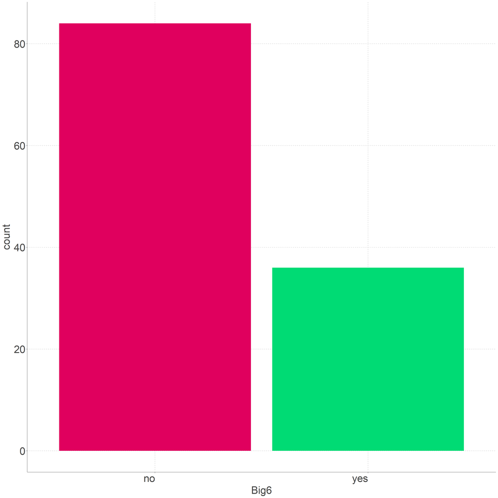

Wykres 8: Przed wyrównaniem

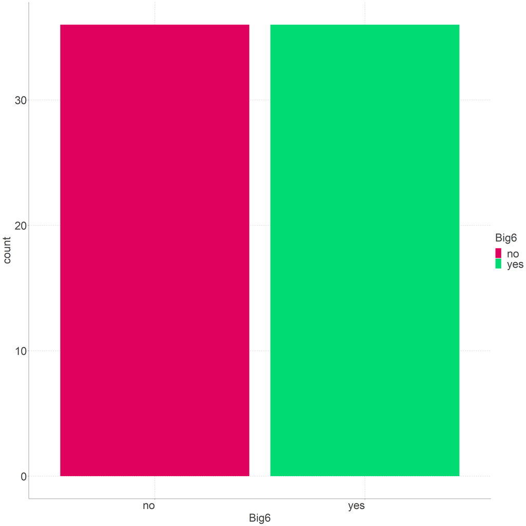

Wykres 9: Po wyrównaniu

Teraz w naszym zbiorze pozostały 72 drużyny to w dalszym ciągu wystarczająco.

#### Rozkład normalny

| method | p.value |
| --- | --- |
| multivariate Shapiro-Wilk normality test | 1.59459821342705e-12 |

Na podstawie testu Shapiro-Wilka odrzucamy również hipotezę o wielowymiarowej normalności. Jednak wielu analityków pomija badanie tego założenia, więc nie będziemy się tym przejmować. Jedziemy dalej!

#### Równość macierzy kowariancji

| method | p.value |
| --- | --- |
| Box's M-test for Homogeneity of Covariance Matrices | 0.0064094 |

Hipotezę o równości macierzy kowariancji również odrzucamy, ale dzięki temu, że obie grupy są równoliczne możemy przymknąć na to oko ;)

### Budowa modelu predykcyjnego

Jednym z naszych głównych celów analizy było sprawdzenie czy określenie Big six jest dalej aktualne. Do wytrenowania modelu analizy dyskryminacyjnej posłużymy się całym zbiorem danych a następnie przetestujemy go na danych z aktualnego sezonu (na dzień 28 Stycznia 2024r). Warto zaznaczyć, że jesteśmy dopiero na półmetku sezonu i mimo ustandaryzowania zmiennych wyniki mogą nie być adekwatne.

### Weryfikacja modelu

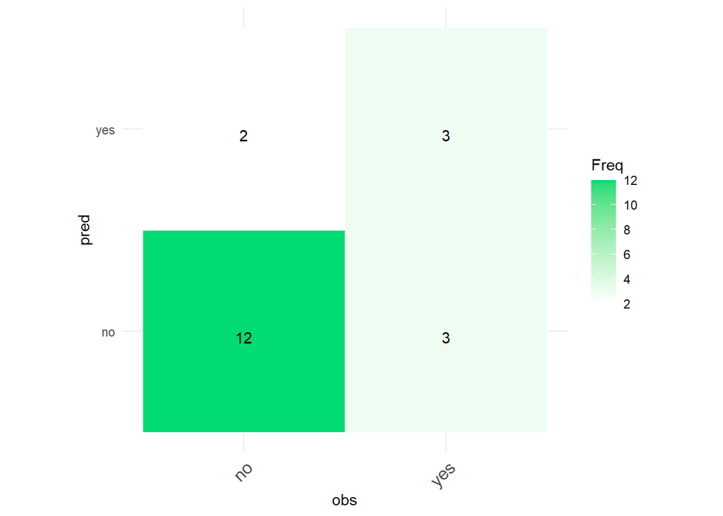

**Miary macierzy pomyłek**

- Accuracy = 75%
- Error rate = 25%
- Sensitivity = 50%
- Specificity = 85.71%

Widzimy, że ogólnie nasz model poradził sobie nienajgorzej z klasyfikacją ponieważ miał rację w 75%, natomiast nam najbardziej zależało aby ‘odnaleźć’ drużyny z Big six to zadanie udało mu się połowicznie. Zobaczmy teraz jakie drużyny zostały zaklasyfikowane do tego grona.

| Drużyna | Predykcja |
| --- | --- |
| Liverpool | yes |
| Manchester City | yes |
| Arsenal | no |
| Aston Villa | no |
| Tottenham | no |
| West Ham | yes |
| Brighton | no |
| Manchester Utd | yes |
| Chelsea | no |
| Newcastle Utd | yes |
| Wolves | no |
| Bournemouth | no |
| Fulham | no |
| Brentford | no |
| Crystal Palace | no |
| Nott'ham Forest | no |
| Everton | no |
| Luton Town | no |
| Burnley | no |
| Sheffield Utd | no |

# Podsumowanie

- Styl gry jaki wyróżnia najlepsze zespoły można podsumować jako krótkie podania głównie na połowie przeciwnika, wysoki pressing czyli odbiór piłki jeszcze na połowie rywala, nie czekając na rozwój akcji. Lepsze drużyny również wyróżniają się na tle wykonywania stałych fragmentów gry.
- Można wyraźnie zaobserwować odrębność Big six na tle reszty zestawienia, ale możemy podejrzewać, że z czasem ta różnica się zaciera patrząc na wyniki tych drużyn w obecnym sezonie i nasz model predykcyjny.